# 0 — What a Robot Is

The Five-Layer Robot Stack · SOC4180 Robot and AI

Hong Jeong

## Before we build anything

The word **robot** is used for at least five different things, and people arguing about robotics are usually arguing about different layers.

Today we build the vocabulary for the whole semester:

1. What the five layers are
2. What each one is responsible for
3. How a **real** robot and a **simulated** robot map onto each other
4. Which layers this course actually lives in

By the end you should be able to hear any robotics claim and ask: *which layer is this about?*

## Why a robot has layers at all

Every robot, real or simulated, runs the same loop:

> **sense → decide → act → the world changes → sense again**

The loop is layered for one hard engineering reason: **the parts run at wildly different speeds.**

A motor must be corrected thousands of times a second. A decision about *where to walk* need not be revised more than once a second. Bolting those together in one program produces something that is both too slow and too twitchy.

Written as equations, one loop is three functions, and each is a layer:

$$x_{k+1} = f(x_k, u_k)\qquad y_k = h(x_k)\qquad u_k = \pi(y_k)$$

$f$ is the world (Layer 1), $h$ is what the sensors declared in the model can see (Layer 2), and $\pi$ is everything that decides (Layers 4 and 5). The whole semester is about $\pi$; the first half writes it by hand, the second half learns it.

**Layers are a consequence of timescales, not of tidiness.**

## The five layers

| # | Layer | Nickname | Answers |
| --- | --- | --- | --- |
| 1 | Physics / World | the body’s reality | What happens when forces act? |
| 2 | Robot Model | the blueprint | What *is* this robot? |
| 3 | Middleware / Robot OS | the nervous system | How do the parts talk? |
| 4 | Control & Planning | the brainstem | What should the motors do *now*? |
| 5 | AI / Behavior | the cortex | What should the robot *achieve*? |

Bottom is fast and dumb. Top is slow and smart.

## The stack, drawn

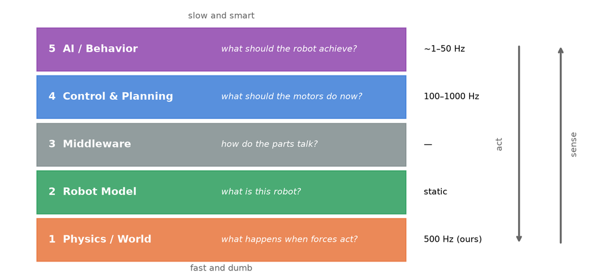

# Layer 1 — Physics / World

## Layer 1: what it is

The layer that answers *“given these forces, what happens next?”*

**On a real robot there is no physics layer — there is only reality.** Gravity is not computed. Friction is not a parameter. The world simply behaves.

**In simulation, a physics engine substitutes for reality.** This is the one layer that exists only in simulation, and it is the layer responsible for every way that simulation lies to you.

## Layer 1: physics engines

| Engine | Typical use |
| --- | --- |
| **MuJoCo** | Contact-rich control and RL research — **our engine** |
| PyBullet | Long-standing teaching engine, now largely superseded |
| Isaac Sim / Isaac Lab | GPU-parallel training at industrial scale (NVIDIA) |
| Gazebo | The ROS ecosystem’s default simulator |
| ODE / Bullet / PhysX | Underlying engines used by the above, and by games |

We use MuJoCo because its contact model is good and it is fast enough to train walking policies. Contact is the whole game in legged robotics: everything interesting happens where the foot meets the floor.

## Layer 1: what it computes

- **Integration** — advance the state by one timestep
- **Contact detection and response** — who is touching what, with what force
- **Friction** — whether the foot slips
- **Inertia and mass distribution** — how the body resists being moved
- **Joint limits** — mechanical stops
- **Actuator dynamics** — how a commanded torque becomes an actual torque
- **Sensor simulation** — synthesising IMU, camera, and force readings

Every one of these is an *approximation*, and every one is a place where a policy that works in simulation can fail on hardware.

## Layer 1: our engine’s actual settings

```
timestep   : 0.002 s  ->  500 Hz
integrator : mjINT_IMPLICITFAST
gravity    : [ 0.    0.   -9.81]
```

The physics runs far faster than any decision-making layer above it. Remember that number.

# Layer 2 — Robot Model

## Layer 2: the blueprint

A file describing **what the robot is**: geometry, mass, joints, actuators, and sensors.

| Format | Ecosystem |
| --- | --- |
| **MJCF** (`.xml`) | MuJoCo — **our format** |
| **URDF** | ROS, and the de-facto interchange format |
| **SDF** | Gazebo |
| USD | NVIDIA Omniverse / Isaac |

A model is a *tree of bodies*. Nesting one body inside another **is** the kinematic chain — that nesting is what makes the foot move when the hip turns.

## Layer 2: a correction worth making early

It is tempting to say “the model is the simulation part.”

**That is wrong.** Real robots need models too:

- Inverse kinematics needs link lengths
- Whole-body control needs the mass matrix
- MPC needs a dynamics model to predict with
- State estimation needs to know where the sensors are

The **model** describes the robot; the **physics engine** simulates the world. A real G1 carries a model of itself and has no world simulator. Keep those two apart and Layer 1 versus Layer 2 stops being confusing.

## Layer 2: what is in our G1

```
bodies      nbody = 31
joints      njnt  = 30
coordinates nq    = 36    (position variables)
velocities  nv    = 35    (degrees of freedom)
actuators   nu    = 29    (motors you can command)
sensors     nsen  = 4
keyframes         = ['stand']
```

**`nq` exceeds `nv`.** The floating base stores orientation as a 4-number quaternion but has only 3 rotational freedoms. A robot that can fall over is not a robot arm bolted to a table, and that one extra number is where the whole difficulty of legged robotics begins.

## Layer 2: sensors are declared, not assumed

```
  GYRO             imu-torso-angular-velocity
  ACCELEROMETER    imu-torso-linear-acceleration
  GYRO             imu-pelvis-angular-velocity
  ACCELEROMETER    imu-pelvis-linear-acceleration
```

The G1 declares **two IMUs** — a gyroscope and an accelerometer at both the torso and the pelvis. That is why `nsensor` is 4 rather than 2: twelve numbers per step, three axes each.

Note what is **absent**: no camera, no joint-torque sensors, no foot contact switches. If a controller needs them, you add them to the model.

**A robot cannot sense what its blueprint does not declare.**

## Layer 2: actuators are not joints

```
first actuator : left_hip_pitch_joint
control range  : [-2.531, 2.880] rad
position gain  : 500
gains used across all 29 actuators: [500.]
```

These are **position servos**: you command an *angle*, and an internal proportional loop with gain 500 produces the torque:

$$\tau = k_p\,(\text{ctrl} - q) \;-\; k_v\,\dot q, \qquad k_p = 500$$

A spring pulling the joint toward its setpoint, plus a damper. Week 5 takes this apart; today it is enough to know that a *command* is an angle, and a *torque* is what the spring produces when the joint is not there yet.

Hold on to this — it is about to matter more than anything else today.

# Layer 3 — Middleware / Robot OS

## Layer 3: the nervous system

The plumbing that lets separately-written programs act as one robot.

| System | Notes |
| --- | --- |
| **ROS 2** | The dominant standard; DDS-based publish/subscribe |
| ROS 1 | Legacy, end-of-life, still widely deployed |
| Vendor SDKs | Unitree, Boston Dynamics, Franka — each proprietary |
| LCM | Lightweight messaging from MIT, common in legged robotics |
| YARP | The iCub humanoid ecosystem |
| Drake | Toolbox with its own systems framework (Toyota Research) |

A commercial humanoid is typically driven through its **vendor SDK**, with a **ROS 2 bridge** so the wider ecosystem’s tooling can be used.

## Layer 3: what it actually provides

- **Transport** — moving messages between processes and across machines
- **Interface contracts** — agreed message types, so parts can be swapped
- **Time** — one clock, and the ability to replay logs against it
- **Lifecycle** — starting, stopping, and supervising components
- **Logging** — recording everything, which is how robot bugs actually get found
- **Introspection** — observing a running system without stopping it

Middleware buys you **modularity**: perception, control, and planning become separable programs that different people can write independently.

## Layer 3: why this course skips it

**We do not use ROS 2, and you should know that is a deliberate omission.**

- ROS 2 is effectively Linux-only, and cannot run in Colab
- Installing it reliably consumes the opening weeks of a course
- It solves a problem we do not have: we run **one** process, not twelve

What we lose is real: the industry-standard interface, and career-relevant literacy. If you go into robotics professionally, **learn ROS 2** — but learn it when the distributed-systems problem it solves is a problem you actually have.

In our stack, Layer 3 is a single Python process. For one simulated robot, that is a legitimate architecture rather than a shortcut.

# Layer 4 — Control & Planning

## Layer 4: the brainstem

The layer that answers **“what should the motors do, right now?”** — running hundreds to thousands of times per second, forever.

| Technique | Job |
| --- | --- |
| **PID / PD control** | Drive one joint to one setpoint |
| **Inverse kinematics** | Find joint angles that place the foot *there* |
| **Trajectory generation** | A smooth path between poses |
| **ZMP / LIPM walking** | Where to step so that balance is preserved |
| **Whole-body control** | Many objectives at once, subject to physics |
| **MPC** | Optimise over a predicted future, then re-solve every cycle |

Weeks 2–6 of this course are Layer 4, built from scratch.

## Layer 4: the demonstration that matters

Actuation disabled: every servo is dead. The robot is a rag doll, and Layer 1 does what Layer 1 does.

## Layer 4: measured, not eyeballed

```
torso height after 3 s, servos OFF : 0.142 m
torso height after 3 s, servos ON  : 0.792 m
```

Standing is not a property of the robot. It is a property of the **loop**.

## The same numbers, over time

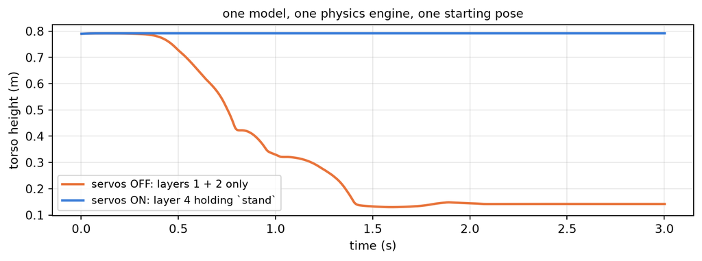

## Layer 4: the trap you must not fall into

A robot with `ctrl = 0` is **not** an uncontrolled robot.

Because the G1’s actuators are position servos, `ctrl = 0` commands *every joint to angle zero* — a straight-legged stance the servos will happily hold. It looks like “doing nothing”, and is in fact a control policy.

> **Zero command is a command.**

To see a robot with no controller you must disable actuation, as we just did. This distinction has ruined many debugging sessions, and it is the honest answer to *“why does my robot not fall when I do nothing?”*

# Layer 5 — AI / Behavior

## Layer 5: the cortex

The layer that answers **“what should the robot achieve?”** — and increasingly, the layer that *replaces* hand-written parts of Layer 4.

| Technique | Job |
| --- | --- |
| **Reinforcement learning** | Learn a locomotion policy from experience |
| **Imitation learning** | Copy demonstrated motion |
| Vision models | Turn pixels into state |
| Navigation policies | Choose where to go |
| Task planning | Decompose a goal into steps |
| Vision-language-action models | Map instructions to robot actions |

Weeks 8–14 are Layer 5. This is where the “AI” in the course title lives.

## Layer 5: the honest scope of learning

Learned policies have largely won at **locomotion** — walking over terrain no hand-written controller handled well.

They have **not** replaced the whole stack:

- The physics engine is still hand-written
- The model is still hand-written
- The low-level joint servos are still classical control
- Safety limits are still hard-coded

A modern RL walking policy typically outputs **joint position targets** at around 50 Hz — which are then tracked by the *same PD servos* from Layer 4, running ten to twenty times faster.

**The learned policy sits on top of classical control. It does not delete it.**

## Timescales: the real reason for layers

| Layer | Typical rate | Why |
| --- | --- | --- |
| 1 Physics | 500 Hz *(ours)* – 1 kHz+ | Contact needs small steps to stay stable |
| 4 Joint servo | 500 Hz – 1 kHz | A motor drifts out of position quickly |
| 4 Balance / WBC | 100 – 500 Hz | Falling happens in a few hundred ms |
| 5 Learned policy | ~50 Hz | Enough for gait; more is wasted compute |
| 5 Navigation | 1 – 10 Hz | The world’s layout changes slowly |
| 5 Task planning | < 1 Hz | Goals change on human timescales |

Roughly three orders of magnitude from bottom to top. **You cannot put a neural network in a 1 kHz loop, and you do not need to.**

## The ladder, on a log axis

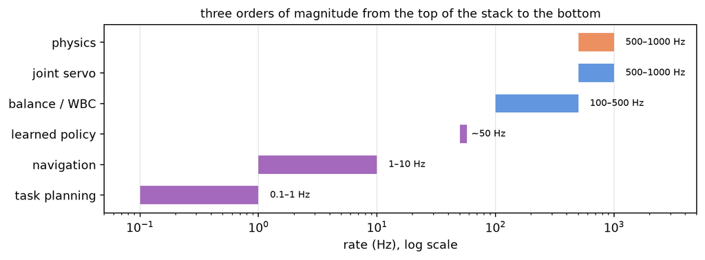

Our policy will run at 50 Hz over 500 Hz physics: **ten physics steps per decision**, and the servos correct the joints ten times between two thoughts.

## Real versus simulated, aligned

| Layer | Real Unitree G1 | Our MuJoCo G1 |
| --- | --- | --- |
| **1 Physics** | Reality itself — nothing computes it | **MuJoCo**, 500 Hz, approximate |
| **2 Model** | Onboard kinematic and dynamic model | **MJCF** from Menagerie, pinned |
| **3 Middleware** | Vendor SDK + ROS 2 bridge | One Python process |
| **4 Control** | Onboard joint servos, WBC, MPC | Controllers we write (weeks 2–6) |
| **5 AI** | Policies deployed to the onboard computer | Policies we train (weeks 8–14) |
| **Body** | Motors, encoders, IMU, battery, frame | Numbers in the MJCF |

**Layers 2–5 transfer between the columns. Layer 1 never does.**

That single asymmetry is the entire sim-to-real problem.

## Where the gap lives

If layers 2–5 are the same code, why does a policy that walks in simulation fall over on hardware?

Because **Layer 1 was replaced by reality**, and reality disagrees:

- Friction is not a constant, and changes with dust, wear, and temperature
- Real motors saturate, heat up, and lag behind their commands
- Real sensors are noisy, biased, and *late*
- Real gearboxes have backlash — a few degrees of nothing before motion starts
- Real mass is never exactly the mass written in the file

None of these appear in the MJCF unless somebody puts them there.

**Week 13** attacks this directly: we build a deliberately worse simulator and measure how far our policies degrade.

## Where this course lives

| Weeks | Layer | What you do |
| --- | --- | --- |
| **0** | all | This lecture — the map |
| **1** | 1 + 2 | Drive the engine; read the blueprint |
| **2–3** | 2 + 4 | Transforms, forward and inverse kinematics |
| **4–5** | 4 | Contact, balance, and **an analytic walking robot** |
| **6** | 4 | Joint control, PD tuning, CPG gaits |
| **7** | 4 → 5 | Reframe walking as a learning problem |
| **8–10** | 5 | Policy gradients, PPO, reward design |
| **11–12** | 5 | Parallel training on GPU; robustness |
| **13** | 1 | The sim-to-real gap, measured |
| **14–15** | 5 | Perception, and the capstone |

We spend the first half **building Layer 4 by hand**, so that when Layer 5 replaces it you know exactly what it replaced.

## What this course does not cover

Stated plainly, so you can fill the gaps deliberately:

- **ROS 2** (Layer 3) — the industry standard; learn it separately
- **Hardware** — no physical robot exists for this course
- **Mechanical design** — motors, gearboxes, and structures are given
- **Electronics and embedded firmware** — below Layer 1 entirely
- **Manipulation** — we walk; we do not grasp

A full humanoid robotics *program* covers all of these. One semester covers the column from physics to policy, and covers it properly.

## The question to carry all semester

For any robotics claim, paper, demo, or product announcement:

> **Which layer is this, and what is it assuming about the layers beneath it?**

A great deal of robotics hype is a Layer 5 result quietly relying on a Layer 1 that does not exist outside the laboratory.

## Lab class: on your laptop

```bash
uv run weeks/00-robot-stack/lab_stack.py
```

Each key leaves a different set of layers on: `1` physics and model only, `0` the `ctrl = 0` trap, `2` servos holding `stand`, `3` the week 4 walker, `4` `my_controller` (complete as shipped; change it), `G` Moon gravity. Contact forces are drawn as arrows — Layer 1, visible. The code is complete and explained.

| Step | Do | Right looks like |
| --- | --- | --- |
| 1 | `1`, `R`, `2` | torso 0.13 m vs 0.792 m; one sentence on which layer differs |
| 2 | `R`, `0` | a standing robot at 0.791 m, and why zero is a command |
| 3 | `G`, `R`, `1`; then `3` | a slow fall, 54 N of contact force; a walker that does not know it is on the Moon |
| 4 | `4`, change `my_controller` | the arm waves, the robot stands; which layer keeps it up |
| 5 | `ENTER` standing, then walking | 327.1 N on 8 contacts; then 280–340 N on 4–5, and why |
| 6 | ctrl-drag under `2` and `3` | no reaction either way: the missing layer named |

## Lab class: `stack.py`, the stack you read

```bash
uv run weeks/00-robot-stack/stack.py --layer hold
uv run weeks/00-robot-stack/stack.py --layer limp --seconds 3
uv run weeks/00-robot-stack/stack.py --layer walk --seconds 9
uv run weeks/00-robot-stack/stack.py --layer wave --gravity 1.62 --no-viewer
```

| Step | Does | Calls |
| --- | --- | --- |
| 1 | layers 1+2: robot, gravity, weight | `load_g1`, `keyframe_data`, `opt.gravity`, `body_mass` |
| 2 | layer 4: pick the controller | `key_ctrl`, `WalkingController`, the actuation disable bit |
| 3 | controller writes `ctrl`, one physics step, 500× a second | `mj_step`, `mj_contactForce` |
| 4 | summary: steps/s, distance, warnings | `data.warning` |
| 6 | replay the recorded `qpos` | `launch_viewer(passive=True)`, `mj_forward`, `sync` |

Measured: `hold` 0.792 m and 327.1 N for ever; `limp` 0.134 m; `walk` 1.03 m in 9 s; ~15,000 physics steps/s here, 30× real time.

## Exercises

1. **Classify.** Name the layer for each: *a URDF file · PPO · a PID gain · a DDS topic · a friction coefficient · a foot trajectory · “fetch me a cup”.*
2. **Zero is a command.** Run the fall demo with actuation *enabled* and `ctrl = 0`. Explain in two sentences why the robot does not collapse.
3. **Break Layer 1.** Set `model.opt.gravity` to the Moon’s $-1.62\ \mathrm{m/s^2}$ and re-run the limp fall. Which other layers had to change? (None — that is the point.)
4. **Sensor absence.** The G1 model declares no foot contact sensors. Name one Layer 4 technique from these slides that becomes harder without them.
5. **Timescale.** A policy runs at 50 Hz while physics runs at 500 Hz. How many physics steps pass between two policy decisions, and what must the servos do in between?

## Next: 01

We stop talking about the stack and start driving it — loading the model, stepping the engine, and rendering what comes out.

Bring today’s vocabulary. Every week from here names its layer.